# Getting Started with spatialAtomizeR

Yunzhe Qian (Bella), Principal Investigators: Dr. Nancy Krieger and Dr. Rachel Nethery

2026-11-22

## Overview

`spatialAtomizeR` implements atom-based Bayesian regression methods (ABRM) for spatial data with misaligned grids. This vignette demonstrates the basic workflow for analyzing misaligned spatial data using both simulated and real-world examples.

## Installation

```r
# Install from CRAN
install.packages("spatialAtomizeR")

# Or install development version from GitHub
# devtools::install_github("bellayqian/spatialAtomizeR")
```

## Load Required Packages

```r
library(spatialAtomizeR)
```

# Example 1: Simulated Data

This example demonstrates the complete workflow using simulated data.

## Step 1: Simulate Misaligned Data

```r
sim_data <- simulate_misaligned_data(
  seed = 42,

  # Distribution specifications for covariates
  dist_covariates_x = c('norm', 'pois', 'binom'),
  dist_covariates_y = c('norm', 'pois', 'binom'),
  dist_y = 'pois',  # Outcome distribution

  # Intercepts for data generation (REQUIRED)
  x_intercepts = c(4, -1, -1),      # One per X covariate
  y_intercepts = c(4, -1, -1),      # One per Y covariate
  beta0_y = -1,                     # Outcome model intercept

  # Spatial correlation parameters
  x_correlation = 0.5,  # Correlation between X covariates
  y_correlation = 0.5,  # Correlation between Y covariates

  # True effect sizes for outcome model
  beta_x = c(-0.03, 0.1, -0.2),    # Effects of X covariates
  beta_y = c(0.03, -0.1, 0.2)      # Effects of Y covariates
)
```

The simulated data object contains: - `gridx`: X-grid spatial features with covariates - `gridy`: Y-grid spatial features with covariates and outcome - `atoms`: Atom-level spatial features (intersection of grids) - `true_params`: True parameter values used in simulation

## Step 2: Examine Simulated Data

The `simulate_misaligned_data` function returns an object of class `misaligned_data` with useful S3 methods:

```r
# Check the class
class(sim_data)
```

```
#> [1] "misaligned_data"
```

```r
# Print method shows basic information
print(sim_data)
```

```
#> Simulated Misaligned Spatial Data
#> ==================================
#> Y-grid cells: 25
#> X-grid cells: 30
#> Atoms: 35
#> Number of X covariates: 3
#> Number of Y covariates: 3
#> True parameters available
```

```r
# Summary method shows more details
summary(sim_data)
```

```
#> Simulated Misaligned Spatial Data
#> ==================================
#> Y-grid cells: 25
#> X-grid cells: 30
#> Atoms: 35
#> Number of X covariates: 3
#> Number of Y covariates: 3
#> True parameters available
#> True beta_x: -0.03, 0.1, -0.2
#> True beta_y: 0.03, -0.1, 0.2
```

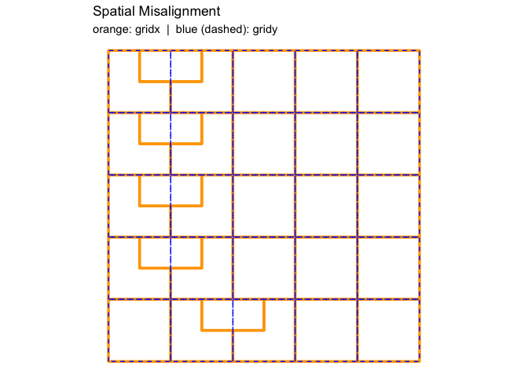

```r
# Default: overlay both grids to visualise misalignment
plot(sim_data)
```

## Step 3: Get ABRM Model Code

Retrieve the pre-compiled NIMBLE model specification:

```r
model_code <- get_abrm_model()
```

## Step 4: Run ABRM Analysis

Fit the ABRM model. Say which distribution each covariate follows with `x_types` (one entry per X-grid covariate) and `y_types` (one per Y-grid covariate), and the outcome distribution with `dist_y`. Each is `"norm"`, `"pois"` or `"binom"`. Covariates are taken from columns named `covariate_x_1`, `covariate_x_2`, … by default; use `x_vars`, `y_vars` and `outcome` to point to columns with other names (see the Utah example below).

```r
abrm_results <- run_abrm(
  gridx = sim_data$gridx,
  gridy = sim_data$gridy,
  atoms = sim_data$atoms,
  model_code = model_code,
  # Optional: true coefficients, for validation. simulate_misaligned_data()
  # returns them in the right format; for your own values use abrm_params().
  true_params = sim_data$true_params,

  # Distribution of each covariate, in the order of the columns
  x_types = c("norm", "pois", "binom"),
  y_types = c("norm", "pois", "binom"),

  # Outcome distribution: "norm", "pois" or "binom"
  dist_y = "pois",

  # MCMC parameters
  niter = 50000,    # Total iterations per chain
  nburnin = 30000,  # Burn-in iterations
  nchains = 2,      # Number of chains
  seed = 123,
  compute_waic = TRUE
)
```

## Step 5: Examine ABRM Results

The `run_abrm` function returns an object of class `abrm` with S3 methods:

```r
# Check the class
class(abrm_results)
```

```
#> [1] "abrm"
```

```r
# Print method shows summary statistics
print(abrm_results)
```

```
#>
#> ABRM Model Results
#> ==================
#> Parameters estimated: 7
#> Converged (R-hat < 1.1, ESS > 400): 0 of 7 parameters
#> Mean absolute bias:  0.3978
#> Coverage rate:       100 %
#>
#> Use summary() for the full parameter table and mcmc_diagnostics() for
#> convergence details.
```

```r
# Summary method shows detailed parameter estimates
summary(abrm_results)
```

```
#> ABRM Model Summary
#> ==================
#> Parameters estimated: 7
#> Mean absolute bias:  0.3978
#> Coverage rate:  100 %
#>
#>       variable parameter estimated_beta std_error ci_lower ci_upper true_beta
#>      intercept  beta_0_y       -1.67783    1.9223  -5.0299  2.89020     -1.00
#>  covariate_x_1 beta_x[1]       -0.27413    0.1737  -0.6069  0.07413     -0.03
#>  covariate_x_2 beta_x[2]       -0.80958    0.7362  -2.2541  0.67667      0.10
#>  covariate_x_3 beta_x[3]       -0.34474    0.8739  -2.1228  1.29564     -0.20
#>  covariate_y_1 beta_y[1]       -0.15297    0.1783  -0.5349  0.19721      0.03
#>  covariate_y_2 beta_y[2]       -0.01665    0.7163  -1.3823  1.43192     -0.10
#>  covariate_y_3 beta_y[3]       -0.34171    0.8272  -1.8962  1.29124      0.20
#>      bias relative_bias within_ci
#>  -0.67783         67.78      TRUE
#>  -0.24413        813.77      TRUE
#>  -0.90958       -909.58      TRUE
#>  -0.14474         72.37      TRUE
#>  -0.18297       -609.90      TRUE
#>   0.08335        -83.35      TRUE
#>  -0.54171       -270.85      TRUE
```

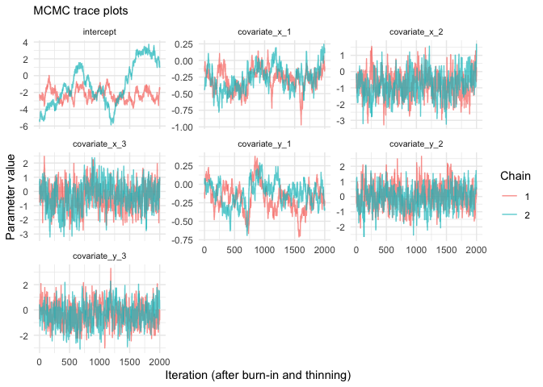

```r
# MCMC trace plots and posterior density plots. Both return ggplot objects,
# so they can be modified or saved with ggplot2::ggsave().
plot_trace(abrm_results)
```

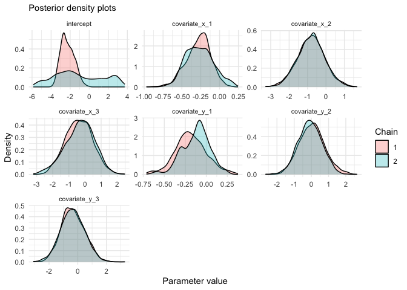

```r
plot_density(abrm_results)
```

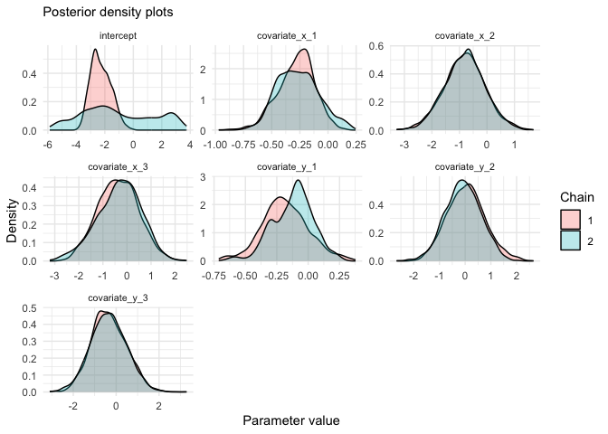

```r
# plot() chooses between the two with 'type'
plot(abrm_results, type = "density")
```

```r
# Convergence diagnostics (R-hat and effective sample size) as a data frame
mcmc_diagnostics(abrm_results)
```

```
#>        variable parameter       mean        sd     rhat       ess converged
#> 1     intercept  beta_0_y -1.6778329 1.9223266 1.368520  24.86387     FALSE
#> 2 covariate_x_1 beta_x[1] -0.2741318 0.1736834 1.010070  52.52954     FALSE
#> 3 covariate_x_2 beta_x[2] -0.8095801 0.7362280 1.000151 247.46975     FALSE
#> 4 covariate_x_3 beta_x[3] -0.3447384 0.8739230 1.004266 258.66960     FALSE
#> 5 covariate_y_1 beta_y[1] -0.1529708 0.1783137 1.060132  33.73336     FALSE
#> 6 covariate_y_2 beta_y[2] -0.0166482 0.7163203 1.014459 296.39036     FALSE
#> 7 covariate_y_3 beta_y[3] -0.3417096 0.8271597 1.000235 361.57656     FALSE
```

## Step 6: More Tests

### Access vairance-covariance matrices from the MCMC posterior sample

```r
# Get variance-covariance matrices
vcov(abrm_results)
```

```
#>
#> Variance-Covariance Matrices for ABRM Model
#> ============================================
#>
#> Intercept Variance:
#>   intercept: 3.69534
#>
#> X-Grid Coefficients Variance-Covariance Matrix:
#>   Dimensions: 3 x 3
#>               covariate_x_1 covariate_x_2 covariate_x_3
#> covariate_x_1      0.030166      0.029117      0.030999
#> covariate_x_2      0.029117      0.542032     -0.030650
#> covariate_x_3      0.030999     -0.030650      0.763741
#>
#> Y-Grid Coefficients Variance-Covariance Matrix:
#>   Dimensions: 3 x 3
#>               covariate_y_1 covariate_y_2 covariate_y_3
#> covariate_y_1      0.031796     -0.046925     -0.000194
#> covariate_y_2     -0.046925      0.513115     -0.066826
#> covariate_y_3     -0.000194     -0.066826      0.684193
#>
#> Use vcov_object$vcov_beta_x, vcov_object$vcov_beta_y, etc. to access matrices
```

```r
# Test coef()
coef(abrm_results)
```

```
#>     intercept covariate_x_1 covariate_x_2 covariate_x_3 covariate_y_1
#>    -1.6778329    -0.2741318    -0.8095801    -0.3447384    -0.1529708
#> covariate_y_2 covariate_y_3
#>    -0.0166482    -0.3417096
```

```r
# Test confint()
confint(abrm_results)
```

```
#>                 CI.Lower   CI.Upper
#> intercept     -5.0298995 2.89019960
#> covariate_x_1 -0.6068795 0.07412711
#> covariate_x_2 -2.2540648 0.67666950
#> covariate_x_3 -2.1228408 1.29564388
#> covariate_y_1 -0.5349459 0.19720562
#> covariate_y_2 -1.3822821 1.43192162
#> covariate_y_3 -1.8962462 1.29124398
```

```r
# Test parm subsetting
confint(abrm_results, parm = "covariate_x_1")
```

```
#>                 CI.Lower   CI.Upper
#> covariate_x_1 -0.6068795 0.07412711
```

```r
# Test fitted()
fitted(abrm_results)
```

```
#>    y_grid_id observed  fitted residual
#> 1          3       18 16.7807   1.2193
#> 2          4       43 40.5083   2.4917
#> 3          5       16 16.5024  -0.5024
#> 4          8       19 21.2597  -2.2597
#> 5          9       17 17.1547  -0.1547
#> 6         10       24 23.7368   0.2632
#> 7         13       32 31.0334   0.9666
#> 8         14       52 46.9606   5.0394
#> 9         15       11 13.1203  -2.1203
#> 10        18       17 18.1927  -1.1927
#> 11        19       18 16.8691   1.1309
#> 12        20       27 25.9617   1.0383
#> 13        21       19 19.1393  -0.1393
#> 14        24       38 35.9470   2.0530
#> 15        25        2  3.5642  -1.5642
#> 16         1      107 50.0572  56.9428
#> 17         2       94 50.2089  43.7911
#> 18         6       69 31.2000  37.8000
#> 19         7       44 24.0623  19.9377
#> 20        11       45 34.7179  10.2821
#> 21        12       82 38.5541  43.4459
#> 22        16       76 27.7001  48.2999
#> 23        17       27 40.6513 -13.6513
#> 24        22       19 26.6552  -7.6552
#> 25        23       36 39.7380  -3.7380
```

```r
# waic_abrm Objects
w <- waic(abrm_results)
print(w)          # shows WAIC, lppd, pWAIC, n_params
```

```
#> WAIC for ABRM
#> =============
#> WAIC   : 1052.743
#> lppd   : -464.833  (log pointwise predictive density)
#> pWAIC  : 61.539  (effective number of parameters)
#>
#> Note: lower WAIC indicates better predictive fit.
#>       Compare only models fitted on identical data.
```

```r
w$waic            # the raw scalar if you need it for comparison
```

```
#> [1] 1052.743
```

# Example 2: Real Data - Utah Counties and School Districts

This example demonstrates using real spatial data from Utah, matching the analysis in the manuscript.

## Load Required Packages for Spatial Data

```r
library(tigris)    # For US Census shapefiles
library(sf)        # Spatial features
library(sp)        # Spatial objects
library(spdep)     # Spatial dependence
library(dplyr)     # Data manipulation
library(ggplot2)   # Plotting
library(raster)    # Only for reading the LandScan population raster in Step 4
```

## Step 1: Load Utah Shapefiles

```r
set.seed(500)

# Load Utah counties (Y-grid)
cnty <- counties(state = 'UT')
```

[output not shown]

```r
gridy <- cnty |>
  rename(ID = GEOID)  # IDs can be character (GEOIDs) or numeric

# Load Utah school districts (X-grid)
scd <- school_districts(state = 'UT')
```

[output not shown]

```r
gridx <- scd |>
  rename(ID = GEOID)
```

## Step 2: Visualize Spatial Misalignment

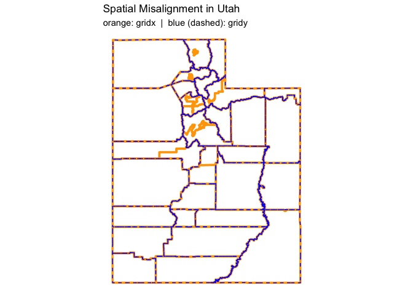

```r
# Bundle grids into a misaligned_data object
utah_mis <- structure(
  list(gridy = gridy, gridx = gridx),
  class = "misaligned_data"
)

# Default overlay plot
plot(utah_mis, color_x = "orange", color_y = "blue", title   = "Spatial Misalignment in Utah")
```

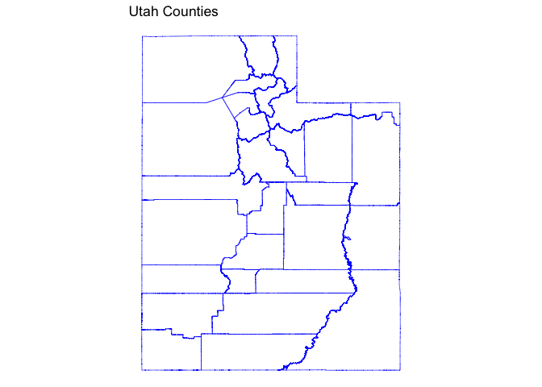

```r
# You can also inspect each grid separately
plot(utah_mis, which = "gridy", title = "Utah Counties")
```

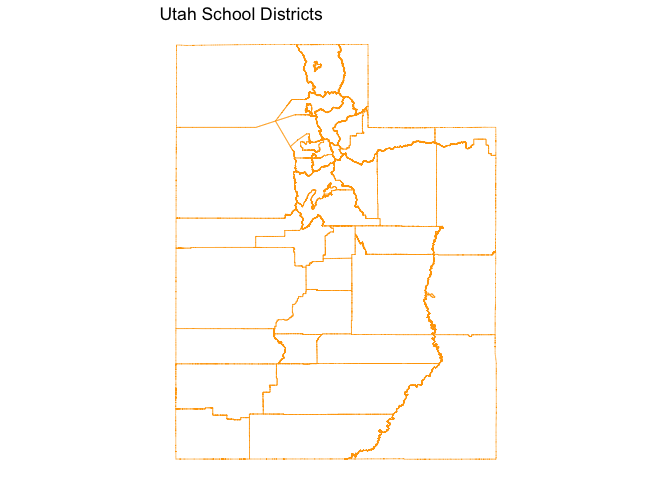

```r
plot(utah_mis, which = "gridx", title = "Utah School Districts")
```

## Step 3: Create Atoms by Intersecting Grids

```r
# Intersect the two grids to create atoms, using only the sf package.
# The result has columns ID_y and ID_x holding the Y-grid and X-grid ID of
# each atom. Point and line pieces where boundaries merely touch are dropped.
atoms <- create_atoms(gridy, gridx)
```

## Step 4: Add Atom-Level Population Counts

ABRM requires population counts at the atom level. Here we use LandScan gridded population data:

```r
# NOTE: You must download LandScan data separately
# Available at: https://landscan.ornl.gov/
# This example assumes the file is in your working directory

pop_raster <- raster("landscan-global-2022.tif")

# Extract population for each atom
pop_atoms <- raster::extract(
  pop_raster,
  st_transform(atoms, crs(pop_raster)),
  fun = sum,
  na.rm = TRUE
)

atoms$population <- pop_atoms
```

## Step 5: Generate Semi-Synthetic Outcome and Covariates

For demonstration, we generate synthetic outcome and covariate data at the atom level:

```r
# Create atom-level spatial adjacency matrix
W_a <- nb2mat(
  poly2nb(as(atoms, "Spatial"), queen = TRUE),
  style = "B",
  zero.policy = TRUE
)

# Generate spatial random effects
atoms <- atoms |>
  mutate(
    re_x = gen_correlated_spat(W = W_a, n_vars = 1, correlation = 1, rho = 0.8),
    re_z = gen_correlated_spat(W = W_a, n_vars = 1, correlation = 1, rho = 0.8),
    re_y = gen_correlated_spat(W = W_a, n_vars = 1, correlation = 1, rho = 0.8)
  )

# Generate atom-level covariates and outcome
atoms <- atoms |>
  mutate(
    # X-grid covariate (Poisson)
    covariate_x_1 = rpois(
      n = nrow(atoms),
      lambda = population * exp(-1 + re_x)
    ),
    # Y-grid covariate (Normal)
    covariate_y_1 = rnorm(
      n = nrow(atoms),
      mean = population * (3 + re_z),
      sd = 1 * population
    )
  ) |>
  mutate(
    # Outcome (Poisson)
    y = rpois(
      n = nrow(atoms),
      lambda = population * exp(
        -5 +
        1 * (covariate_x_1 / population) -
        0.3 * (covariate_y_1 / population) +
        re_y
      )
    )
  )
```

## Step 6: Aggregate to Observed Grids

In reality, we only observe aggregated data at the grid level, not at atoms:

```r
# Aggregate X covariates to X-grid
gridx[["covariate_x_1"]] <- sapply(gridx$ID, function(j) {
  atom_indices <- which(atoms$ID_x == j)
  sum(atoms[["covariate_x_1"]][atom_indices])
})

# Aggregate Y covariates to Y-grid
gridy[["covariate_y_1"]] <- sapply(gridy$ID, function(j) {
  atom_indices <- which(atoms$ID_y == j)
  sum(atoms[["covariate_y_1"]][atom_indices])
})

# Aggregate outcome to Y-grid
gridy$y <- sapply(gridy$ID, function(j) {
  atom_indices <- which(atoms$ID_y == j)
  sum(atoms$y[atom_indices])
})
```

## Step 7: Run ABRM on Real Data

```r
model_code <- get_abrm_model()

mcmc_results <- run_abrm(
  gridx = gridx,
  gridy = gridy,
  atoms = atoms,
  model_code = model_code,

  # Covariate and outcome columns (any names; here the defaults)
  x_vars = "covariate_x_1",
  y_vars = "covariate_y_1",
  outcome = "y",

  # Distributions: one entry per covariate
  x_types = "pois",   # X covariate is Poisson
  y_types = "norm",   # Y covariate is Normal
  dist_y = "pois",    # Outcome is Poisson

  # MCMC settings (increase for real analysis)
  niter = 300000,
  nburnin = 200000,
  nchains = 2,
  seed = 123,
  compute_waic = TRUE
)
```

## Step 8: Examine Real Data Results

```r
# View results from the Utah model fit
summary(mcmc_results)

# Get variance-covariance matrices
vcov(mcmc_results)

# Coefficient estimates
coef(mcmc_results)

# 95% confidence intervals
confint(mcmc_results)

# WAIC
w <- waic(mcmc_results)
print(w)
```

# Understanding Distribution Types

`x_types` and `y_types` list the distribution of each covariate, in the same order as the covariate columns (`x_vars` / `y_vars`):

```r
dist_covariates_x = c('norm', 'pois', 'binom')

# So you would specify:
x_types = c("norm", "pois", "binom")
```

## Distribution Type Codes

| Distribution | Value | Use Case |
| --- | --- | --- |
| Normal | `"norm"` | Continuous data |
| Poisson | `"pois"` | Count/rate data |
| Binomial | `"binom"` | Proportion/binary data |

The long forms `"normal"`, `"poisson"` and `"binomial"` are also accepted. The same values are used for `dist_y`.

## Getting Help

- Function documentation: `?simulate_misaligned_data`, `?run_abrm`
- Report issues: https://github.com/bellayqian/spatialAtomizeR/issues
- Package help: `?spatialAtomizeR`

# Citation

```r
citation("spatialAtomizeR")
```

**Reference:** Qian, Y., Johnson, N., Krieger, N., & Nethery, R.C. (2026). spatialAtomizeR: Atom-Based Regression Models for Spatially Misaligned Data in R. R package version 0.2.8.